# Assignment 3 - Womens Role

Andrew Pierson

July 17, 2018

## Load Data and Packages

The first step is to load the data, this includes loading the HSAUR3 and rstanarm packages in order to access the data files. The next thing to do is to define the data frame womensrole_df using the womensrole data.

```r
library(HSAUR3)
library(rstanarm)
data("womensrole", package = "HSAUR3")
womensrole_df<-data.frame(womensrole)
```

## Logistic Regression

The total of the responses for agreeing and disagreeing indicate a minimum of zero, median of 32, and a max of 593. The average was 68. Below a logistic regression analysis is also done and indicates both logistic coefficients to be negative values, meaning as the other coefficients increase in value the negative ones will decrease. The coefficients for education and female move linearly.

```r
womensrole$total <- womensrole$agree + womensrole$disagree
summary(womensrole$total)
```

```
##    Min. 1st Qu.  Median    Mean 3rd Qu.    Max.
##    0.00   10.00   32.00   68.36  100.50  593.00
```

```r
womensrole_glm_1 <- glm(cbind(agree, disagree) ~ education + gender,
                        data = womensrole, family = binomial(link = "logit"))
round(coef(summary(womensrole_glm_1)), 3)
```

```
##              Estimate Std. Error z value Pr(>|z|)
## (Intercept)     2.509      0.184  13.646    0.000
## education      -0.271      0.015 -17.560    0.000
## genderFemale   -0.011      0.084  -0.136    0.892
```

## logit Posterior Distribution

Now a bayesian glm will be ran on the womens role dataset, it reveals that the bayesian model determines education to be an inverse coefficient. The model is testing the correlations between a response (agree or disagree) in relation to gender and education. The third predictor indicated in the output below is the intercept or coefficient.

```r
library(rstanarm)
womensrole_bglm_1 <- stan_glm(cbind(agree, disagree) ~ education + gender,
                              data = womensrole,
                              family = binomial(link = "logit"),
                              prior = student_t(df = 7),
                              prior_intercept = student_t(df = 7),
                              chains = 4, cores = 2, seed = 12345, iter=3000)
womensrole_bglm_1
```

```
## stan_glm
##  family:       binomial [logit]
##  formula:      cbind(agree, disagree) ~ education + gender
##  observations: 42
##  predictors:   3
## ------
##              Median MAD_SD
## (Intercept)   2.5    0.2
## education    -0.3    0.0
## genderFemale  0.0    0.1
##
## Sample avg. posterior predictive distribution of y:
##          Median MAD_SD
## mean_PPD 24.3    0.8
##
## ------
## For info on the priors used see help('prior_summary.stanreg').
```

```r
summary(womensrole_bglm_1)
```

```
##
## Model Info:
##
##  function:     stan_glm
##  family:       binomial [logit]
##  formula:      cbind(agree, disagree) ~ education + gender
##  algorithm:    sampling
##  priors:       see help('prior_summary')
##  sample:       6000 (posterior sample size)
##  observations: 42
##  predictors:   3
##
## Estimates:
##                 mean   sd     2.5%   25%    50%    75%    97.5%
## (Intercept)      2.5    0.2    2.1    2.4    2.5    2.6    2.9
## education       -0.3    0.0   -0.3   -0.3   -0.3   -0.3   -0.2
## genderFemale     0.0    0.1   -0.2   -0.1    0.0    0.0    0.2
## mean_PPD        24.3    0.8   22.7   23.7   24.3   24.8   25.9
## log-posterior -107.9    1.3 -111.1 -108.4 -107.5 -106.9 -106.4
##
## Diagnostics:
##               mcse Rhat n_eff
## (Intercept)   0.0  1.0  4229
## education     0.0  1.0  4733
## genderFemale  0.0  1.0  5681
## mean_PPD      0.0  1.0  5554
## log-posterior 0.0  1.0  2619
##
## For each parameter, mcse is Monte Carlo standard error, n_eff is a crude measure of effective sample size, and Rhat is the potential scale reduction factor on split chains (at convergence Rhat=1).
```

### Prior Assumptions

Here we will explore the priors that we obtain from the generalized linear model. Exploring the prior distribution after we have established a posterior distribution will eliminate any motivations about the beliefs of a specific model parameter choice.

```r
#Priors
prior_summary(womensrole_bglm_1, digits = 2)
```

```
## Priors for model 'womensrole_bglm_1'
## ------
## Intercept (after predictors centered)
##  ~ student_t(df = 7, location = 0, scale = 10)
##
## Coefficients
##  ~ student_t(df = [7,7], location = [0,0], scale = [2.5,2.5])
##      **adjusted scale = [0.41,2.50]
## ------
## See help('prior_summary.stanreg') for more details
```

```r
priors<-prior_summary(womensrole_bglm_1, digits = 2)
names(priors)
```

```
## [1] "prior"           "prior_intercept"
```

```r
priors$prior$scale
```

```
## [1] 2.5 2.5
```

```r
priors$prior$adjusted_scale
```

```
## [1] 0.4079168 2.5000000
```

### Bayesian Uncertainty Interval

The 95% confidence interval ranges from -0.3 to -0.24.This interval tells us that there is a 95% probability that an observation will be recorded in the distribution between -0.3 and -0.24.

```r
ci95 <- posterior_interval(womensrole_bglm_1, prob = 0.95, pars = "education")
round(ci95, 2)
```

```
##           2.5% 97.5%
## education -0.3 -0.24
```

### Post Estimation

Postestimation is useful to find outliers that are unwanted and can influence the model. Using the median absolute deviation (MAD) and the standard deviation of MAD can essentially be used to trim the dataset of unwanted observations that are not representative of the model’s distribution. For education an outlier would be considered anything outside of -0.2710813 +/- 0.0149786 and for genderFemale anything outside of -0.01020746 +/- 0.08546868 would be considered an outlier.

```r
cbind(Median = coef(womensrole_bglm_1), MAD_SD = se(womensrole_bglm_1))
```

```
##                   Median     MAD_SD
## (Intercept)   2.51173148 0.18207448
## education    -0.27108130 0.01497860
## genderFemale -0.01020746 0.08546868
```

### Traceplots

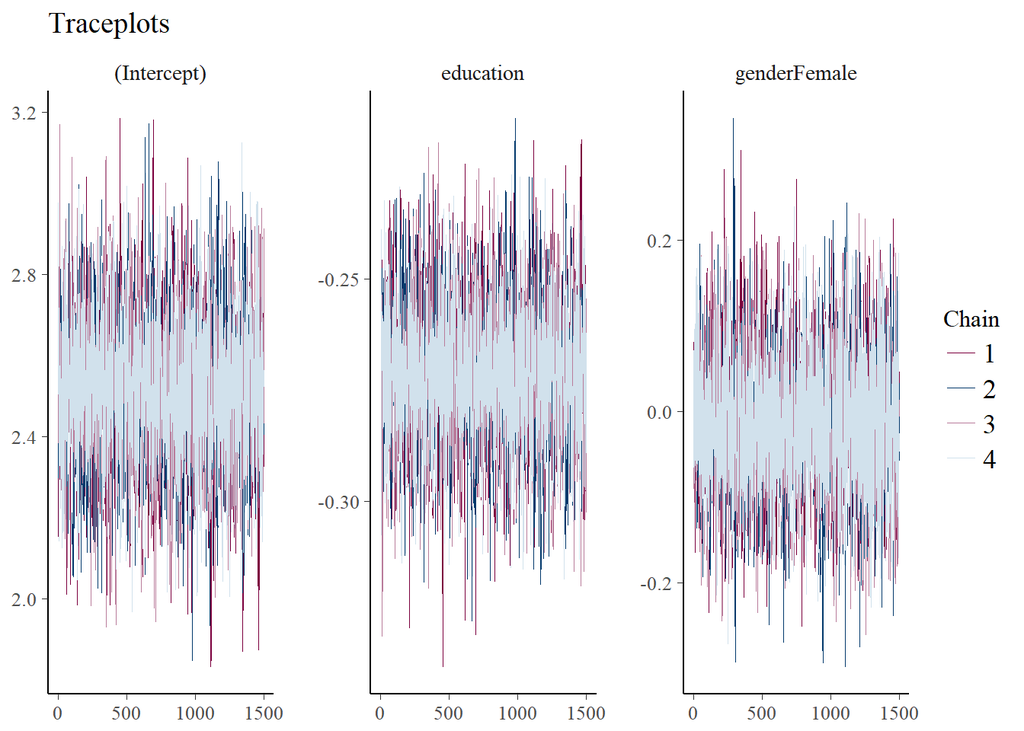

```r
#Traceplots
library(bayesplot)
library(ggplot2)
color_scheme_set("mix-blue-pink")
plot(womensrole_bglm_1, plotfun = "trace") + ggtitle("Traceplots")
```

### Autocorrelation Plots

The Autocorrelation of the education and genderFemale indicates that there is a small amount of error. This is good because if the model had excessive autocorrelation, the model’s specification may have a problem. From these plots we can conclude that the simulation is highly efficient because it has a low autocorrelation.

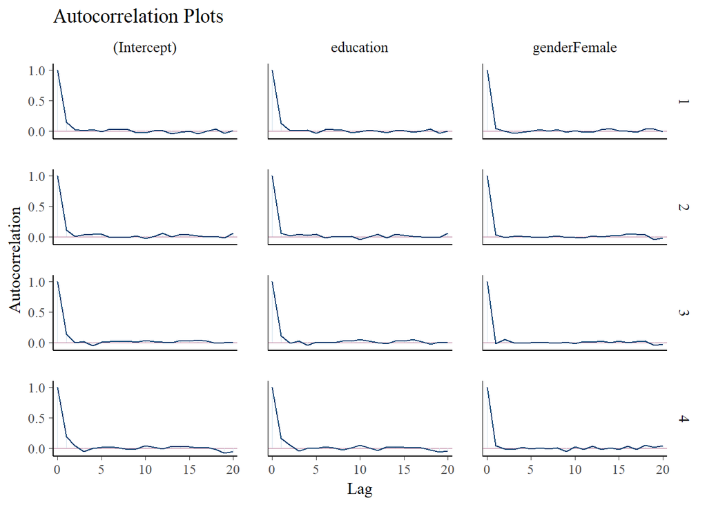

```r
#ACF
plot(womensrole_bglm_1, plotfun = "acf") + ggtitle("Autocorrelation Plots")
```

### Marginal Posterior Parameter Estimates

The marginal errors of our two parameters are small, indicating a weak influence by other parameters. This is usually a positive sign because we want to isolate parameters to have a small marginal error.

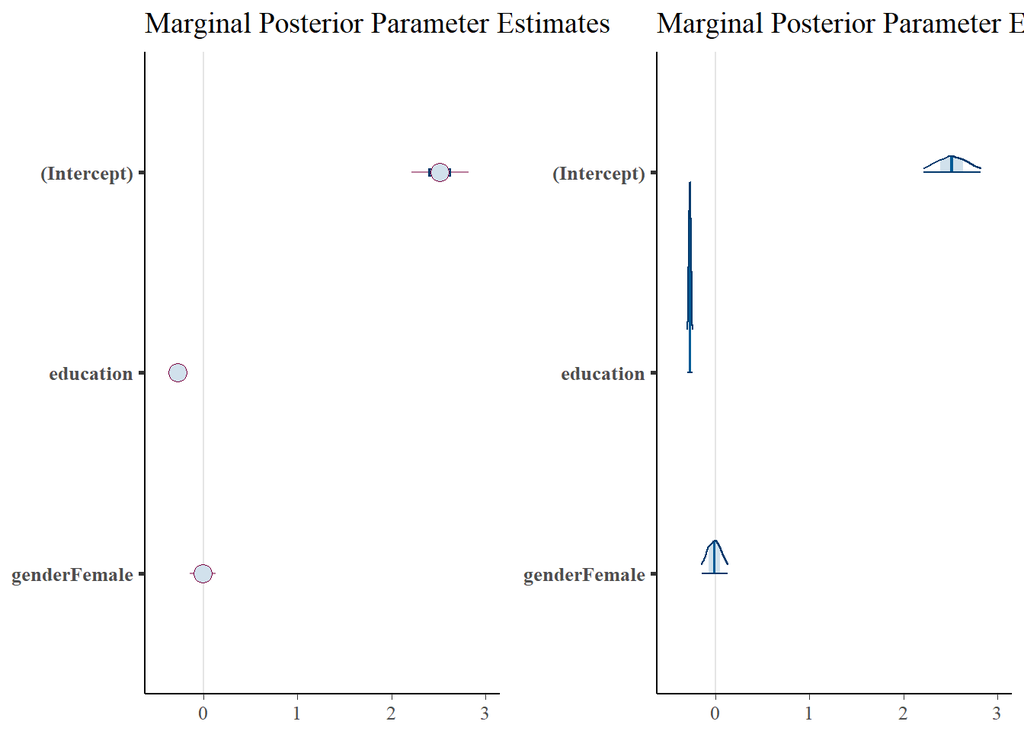

```r
#we are plotting the 50% uncertainty interval (thick horizontal lines) and the 90% uncertainty interval (thin horizontal lines). In terms of interpretation, the 50% uncertainty interval identifies
#where 50% of the marginal distribution lies for each parameter.
bayesplot_grid(
  plot(womensrole_bglm_1, plotfun = "intervals", prob = 0.5, prob_outer = 0.9, point_est = "median") + ggtitle("Marginal Posterior Parameter Estimates"),
  plot(womensrole_bglm_1, plotfun = "areas", prob = 0.5, prob_outer = 0.9, point_est = "median") + ggtitle("Marginal Posterior Parameter Estimates"),
  grid_args = list(ncol = 2)
)
```

### Marginal Posterior Parameter Distributions

The marginal posterior parameter distributions for the logit Monte Carlo Markov Chain (MCMC) model appear to be normalized with a density around what was seen in the traceplots. In addition, the Markov Chains had very little variation in their estimation.

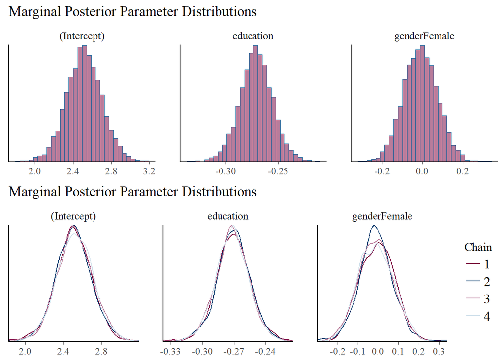

```r
#plot the histograms for each parameter (pooled across chains) and the empirical density of each parameter, respectively.
bayesplot_grid(
  plot(womensrole_bglm_1, plotfun = "hist") + ggtitle("Marginal Posterior Parameter Distributions"),
  plot(womensrole_bglm_1, plotfun = "dens_overlay") + ggtitle("Marginal Posterior Parameter Distributions"),
  grid_args = list(nrow = 2)
)
```

## cloglog Posterior Distribution

```r
library(rstanarm)
womensrole_bglm_1 <- stan_glm(cbind(agree, disagree) ~ education + gender,
                              data = womensrole,
                              family = binomial(link = "cloglog"),
                              prior = student_t(df = 4),
                              prior_intercept = student_t(df = 4),
                              chains = 4, cores = 2, seed = 12345, iter=100)
womensrole_bglm_1
```

```
## stan_glm
##  family:       binomial [cloglog]
##  formula:      cbind(agree, disagree) ~ education + gender
##  observations: 42
##  predictors:   3
## ------
##              Median MAD_SD
## (Intercept)   1.3    0.1
## education    -0.2    0.0
## genderFemale  0.0    0.1
##
## Sample avg. posterior predictive distribution of y:
##          Median MAD_SD
## mean_PPD 24.3    0.8
##
## ------
## For info on the priors used see help('prior_summary.stanreg').
```

```r
summary(womensrole_bglm_1)
```

```
##
## Model Info:
##
##  function:     stan_glm
##  family:       binomial [cloglog]
##  formula:      cbind(agree, disagree) ~ education + gender
##  algorithm:    sampling
##  priors:       see help('prior_summary')
##  sample:       200 (posterior sample size)
##  observations: 42
##  predictors:   3
##
## Estimates:
##                 mean   sd     2.5%   25%    50%    75%    97.5%
## (Intercept)      1.3    0.1    1.1    1.2    1.3    1.4    1.5
## education       -0.2    0.0   -0.2   -0.2   -0.2   -0.2   -0.2
## genderFemale     0.0    0.1   -0.1    0.0    0.0    0.1    0.2
## mean_PPD        24.3    0.8   22.7   23.8   24.3   24.9   25.9
## log-posterior -116.4    1.2 -119.6 -117.2 -116.1 -115.4 -115.1
##
## Diagnostics:
##               mcse Rhat n_eff
## (Intercept)   0.0  1.0  195
## education     0.0  1.0  194
## genderFemale  0.0  1.0  200
## mean_PPD      0.1  1.0  151
## log-posterior 0.1  1.0  126
##
## For each parameter, mcse is Monte Carlo standard error, n_eff is a crude measure of effective sample size, and Rhat is the potential scale reduction factor on split chains (at convergence Rhat=1).
```

### Prior Assumptions

```r
#Priors
prior_summary(womensrole_bglm_1, digits = 2)
```

```
## Priors for model 'womensrole_bglm_1'
## ------
## Intercept (after predictors centered)
##  ~ student_t(df = 4, location = 0, scale = 10)
##
## Coefficients
##  ~ student_t(df = [4,4], location = [0,0], scale = [2.5,2.5])
##      **adjusted scale = [0.41,2.50]
## ------
## See help('prior_summary.stanreg') for more details
```

```r
priors<-prior_summary(womensrole_bglm_1, digits = 2)
names(priors)
```

```
## [1] "prior"           "prior_intercept"
```

```r
priors$prior$scale
```

```
## [1] 2.5 2.5
```

```r
priors$prior$adjusted_scale
```

```
## [1] 0.4079168 2.5000000
```

### Bayesian Uncertainty Interval

The 95% confidence interval ranges from -0.21 to -0.17. This interval tells us that there is a 95% probability that an observation will be recorded in the distribution between -0.21 and -0.17.

```r
ci95 <- posterior_interval(womensrole_bglm_1, prob = 0.95, pars = "education")
round(ci95, 2)
```

```
##            2.5% 97.5%
## education -0.21 -0.17
```

### Post Estimation

```r
cbind(Median = coef(womensrole_bglm_1), MAD_SD = se(womensrole_bglm_1))
```

```
##                  Median      MAD_SD
## (Intercept)   1.2853163 0.106848996
## education    -0.1887082 0.009762977
## genderFemale  0.0325262 0.063622753
```

### Traceplots

The traceplots that result from this Monte Carlo simulation has an extremely random distribution. It is very hard from glancing at the plots to tell where their highest density is located. The education varible appears to have somewhat of a higher density between -0.2 and -0.18 and the genderFemale seems to have a concentration of generated values around 0 and 0.1. The distributions are very random from my interpretation of the traceplots.

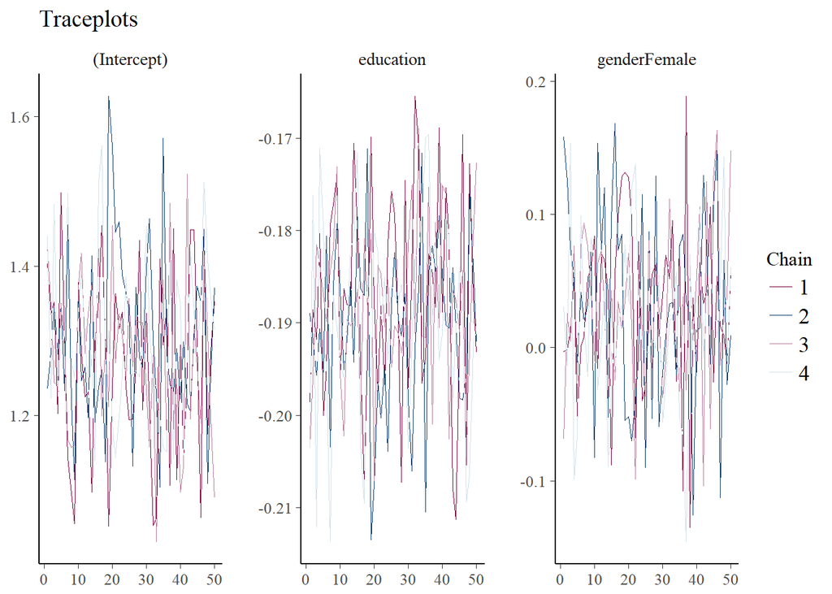

```r
#Traceplots
library(bayesplot)
library(ggplot2)
color_scheme_set("mix-blue-pink")
plot(womensrole_bglm_1, plotfun = "trace") + ggtitle("Traceplots")
```

### Autocorrelation Plots

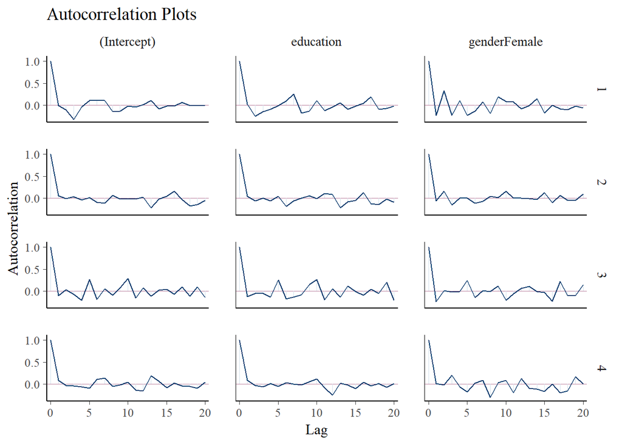

```r
#ACF
plot(womensrole_bglm_1, plotfun = "acf") + ggtitle("Autocorrelation Plots")
```

### Marginal Posterior Parameter Estimates

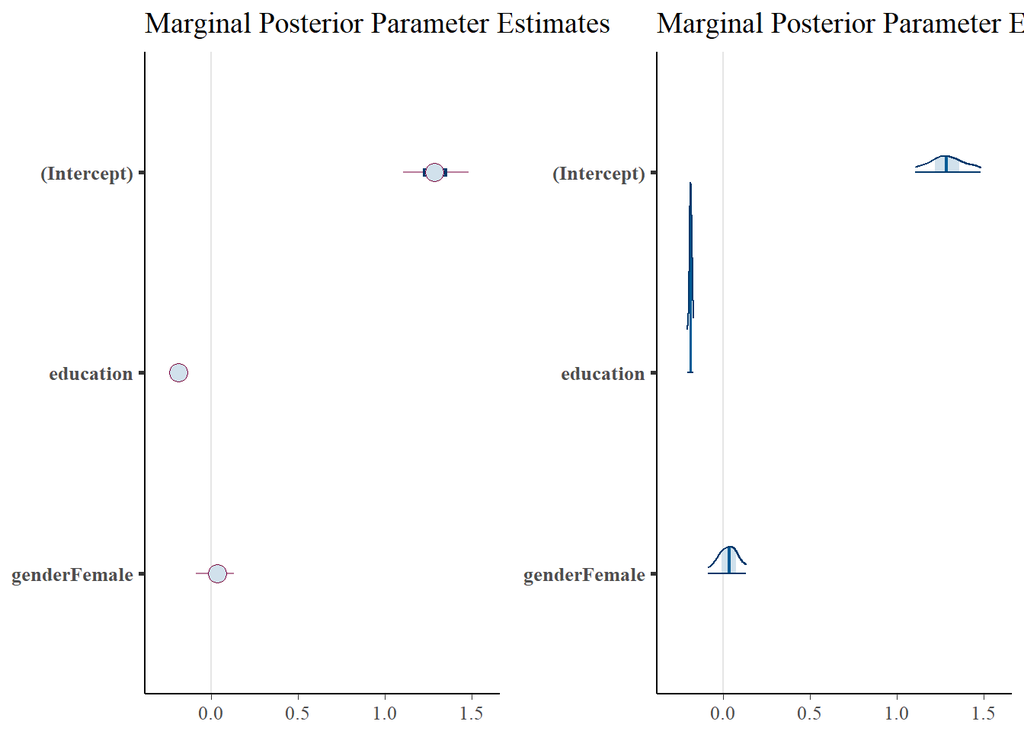

```r
#we are plotting the 50% uncertainty interval (thick horizontal lines) and the 90% uncertainty interval (thin horizontal lines). In terms of interpretation, the 50% uncertainty interval identifies
#where 50% of the marginal distribution lies for each parameter.
bayesplot_grid(
  plot(womensrole_bglm_1, plotfun = "intervals", prob = 0.5, prob_outer = 0.9, point_est = "median") + ggtitle("Marginal Posterior Parameter Estimates"),
  plot(womensrole_bglm_1, plotfun = "areas", prob = 0.5, prob_outer = 0.9, point_est = "median") + ggtitle("Marginal Posterior Parameter Estimates"),
  grid_args = list(ncol = 2)
)
```

### Marginal Posterior Parameter Distributions

The marginal posterior parameter distributions for the cloglog Monte Carlo Markov Chain (MCMC) model appear to be randomly distributed with a density that cannot easily be evaluated, as seen in the model’s traceplots. In addition, the Markov Chains had very high variation in their estimation. Consider running a higher number of iterations.

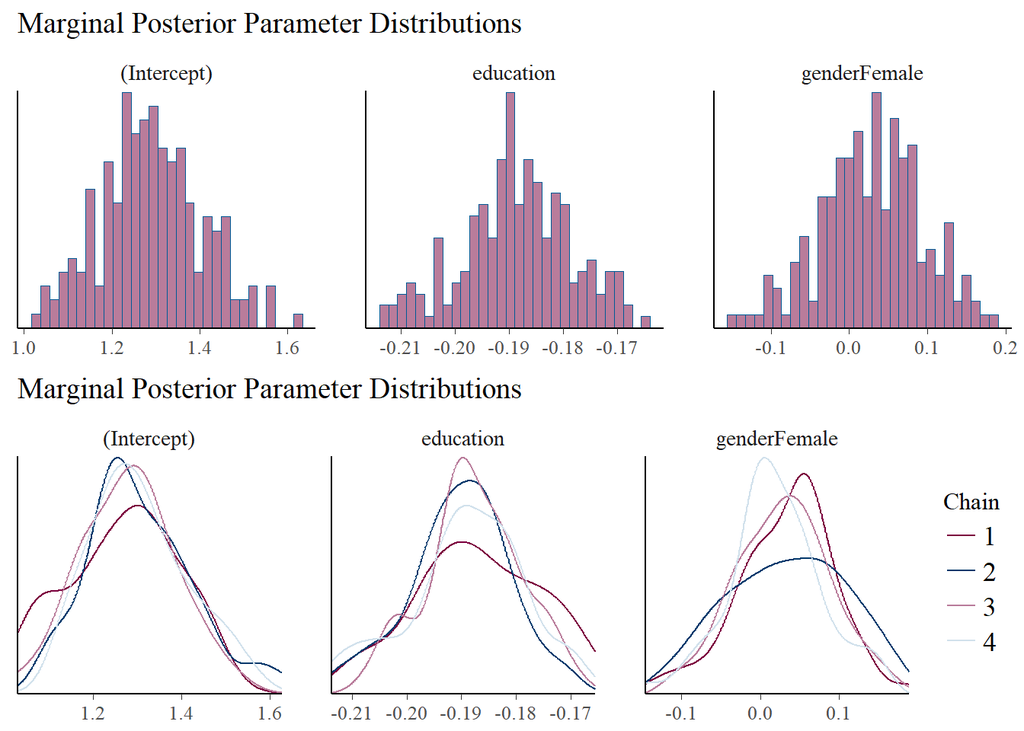

```r
#plot the histograms for each parameter (pooled across chains) and the empirical density of each parameter, respectively.
bayesplot_grid(
  plot(womensrole_bglm_1, plotfun = "hist") + ggtitle("Marginal Posterior Parameter Distributions"),
  plot(womensrole_bglm_1, plotfun = "dens_overlay") + ggtitle("Marginal Posterior Parameter Distributions"),
  grid_args = list(nrow = 2)
)
```